# Tutorial - introduction to METABRIC

# Instructions

You have been provided with an R script to do some analysis. Please run this script step by step. Below is an explanation of the data, and each part of the code.

# Background

This tutorial considers some exploratory analysis of data from METABRIC (Molecular Taxonomy of Breast Cancer International Consortium).

The data were originally used in a study that looked at the patterns of molecules inside tumours. Their conclusion was that ‘breast cancer’ is in fact at least ten different diseases, each with its own molecular fingerprint, and each with different weak spots. You can read about it here:

https://pubmed.ncbi.nlm.nih.gov/27161491/

The data you will analyse were downloaded from [cbioportal.org](https://www.cbioportal.org/study/clinicalData?id=brca_metabric)

# Analysis

The METABRIC data consist of clincal characteristics coupled with gene expression data. In this tutorial we look at the clinical characteristics. This is similar to a first stage in prognostic modelling, to understand the existing factors, before proceeding to investigate the new ones and how they relate to the existing ones.

Only a few simple analyses are done. For additional learning of R, I suggest that you try to conduct your own analysis of other factors.

# Script explanation

## Load the data

Data are already downloaded, and saved in the project (`brca_metabric_clinical_data.tsv`). This is a tab-separated file, and so `read.delim()` is used in place of `read.csv()`. `read.delim()` requires the user to specifiy *what* the separator is, and `"\t"` tells it that it is a tab.

```r
## 1. Load data
mydta = read.delim("brca_metabric_clinical_data.tsv", sep="\t")

## 2. Show first few rows, list column names
head(mydta)
```

```
##        Study.ID Patient.ID Sample.ID Age.at.Diagnosis Type.of.Breast.Surgery
## 1 brca_metabric    MB-0000   MB-0000            75.65             MASTECTOMY
## 2 brca_metabric    MB-0002   MB-0002            43.19      BREAST CONSERVING
## 3 brca_metabric    MB-0005   MB-0005            48.87             MASTECTOMY
## 4 brca_metabric    MB-0006   MB-0006            47.68             MASTECTOMY
## 5 brca_metabric    MB-0008   MB-0008            76.97             MASTECTOMY
## 6 brca_metabric    MB-0010   MB-0010            78.77             MASTECTOMY
##     Cancer.Type                      Cancer.Type.Detailed Cellularity
## 1 Breast Cancer          Breast Invasive Ductal Carcinoma        <NA>
## 2 Breast Cancer          Breast Invasive Ductal Carcinoma        High
## 3 Breast Cancer          Breast Invasive Ductal Carcinoma        High
## 4 Breast Cancer Breast Mixed Ductal and Lobular Carcinoma    Moderate
## 5 Breast Cancer Breast Mixed Ductal and Lobular Carcinoma        High
## 6 Breast Cancer          Breast Invasive Ductal Carcinoma    Moderate
##   Chemotherapy Pam50...Claudin.low.subtype Cohort ER.status.measured.by.IHC
```

[output cut: 55 more lines]

## Summary statistics

```r
summary(mydta)
```

```
##           Study.ID      Patient.ID     Sample.ID    Age.at.Diagnosis
##  brca_metabric:2509   MB-0000:   1   MB-0000:   1   Min.   :21.93
##                       MB-0002:   1   MB-0002:   1   1st Qu.:50.92
##                       MB-0005:   1   MB-0005:   1   Median :61.11
##                       MB-0006:   1   MB-0006:   1   Mean   :60.42
##                       MB-0008:   1   MB-0008:   1   3rd Qu.:70.00
##                       MB-0010:   1   MB-0010:   1   Max.   :96.29
##                       (Other):2503   (Other):2503   NA's   :11
##        Type.of.Breast.Surgery         Cancer.Type
##  BREAST CONSERVING: 785       Breast Cancer :2506
##  MASTECTOMY       :1170       Breast Sarcoma:   3
##  NA's             : 554
##
##
##
##
##                                 Cancer.Type.Detailed   Cellularity
##  Breast                                   :  21      High    :965
##  Breast Invasive Ductal Carcinoma         :1865      Low     :215
##  Breast Invasive Lobular Carcinoma        : 192      Moderate:737
##  Breast Invasive Mixed Mucinous Carcinoma :  25      NA's    :592
##  Breast Mixed Ductal and Lobular Carcinoma: 269
##  Metaplastic Breast Cancer                :   2
##  NA's                                     : 135
##  Chemotherapy Pam50...Claudin.low.subtype     Cohort
##  NO  :1568    LumA       :700             Min.   :1.0
##  YES : 412    LumB       :475             1st Qu.:1.0
##  NA's: 529    Her2       :224             Median :3.0
##               claudin-low:218             Mean   :2.9
##               Basal      :209             3rd Qu.:4.0
##               (Other)    :154             Max.   :9.0
##               NA's       :529             NA's   :11
##  ER.status.measured.by.IHC    ER.Status    Neoplasm.Histologic.Grade
##  Negative: 609             Negative: 644   Min.   :1.000
##  Positve :1817             Positive:1825   1st Qu.:2.000
##  NA's    :  83             NA's    :  40   Median :3.000
##                                            Mean   :2.412
##                                            3rd Qu.:3.000
##                                            Max.   :3.000
##                                            NA's   :121
```

[output cut: 49 more lines]

```
##  ER-/HER2-            :309          Min.   :  1.00   Min.   :0.000
##  ER+/HER2- High Prolif:617          1st Qu.: 17.00   1st Qu.:1.000
##  ER+/HER2- Low Prolif :640          Median : 22.41   Median :2.000
##  HER2+                :198          Mean   : 26.22   Mean   :1.714
##  NA's                 :745          3rd Qu.: 30.00   3rd Qu.:2.000
##                                     Max.   :182.00   Max.   :4.000
##                                     NA's   :149      NA's   :721
##           Patient.s.Vital.Status
##  Died of Disease     :646
##  Died of Other Causes:497
##  Living              :837
##  NA's                :529
##
##
##
```

## Age at diagnosis

The below plots a histogram and boxplot of age on the same plot, with the histogram above the boxplot. The boxplot is orientated horizontally, rather than the default vertical boxplot.

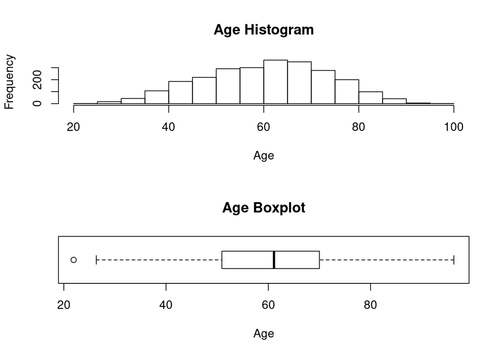

```r
par(mfrow=c(2,1))

hist(mydta$Age.at.Diagnosis, xlab="Age", main="Age Histogram")

boxplot(mydta$Age.at.Diagnosis, xlab="Age", main="Age Boxplot", horizontal=TRUE)
```

## Lymph Nodes

The same plot as for age is repeated for number of lymph nodes.

A difference is use of the `breaks=` argument. This tells R that the bins in the histogram should be with 1 (`by=1`), running from 0 to the maximum in the data (`max(ydta$Lymph.nodes.examined.positive, na.rm=TRUE)`. It is necessary to use the `na.rm=TRUE` argument in `max()` because this variable is not know for all women.

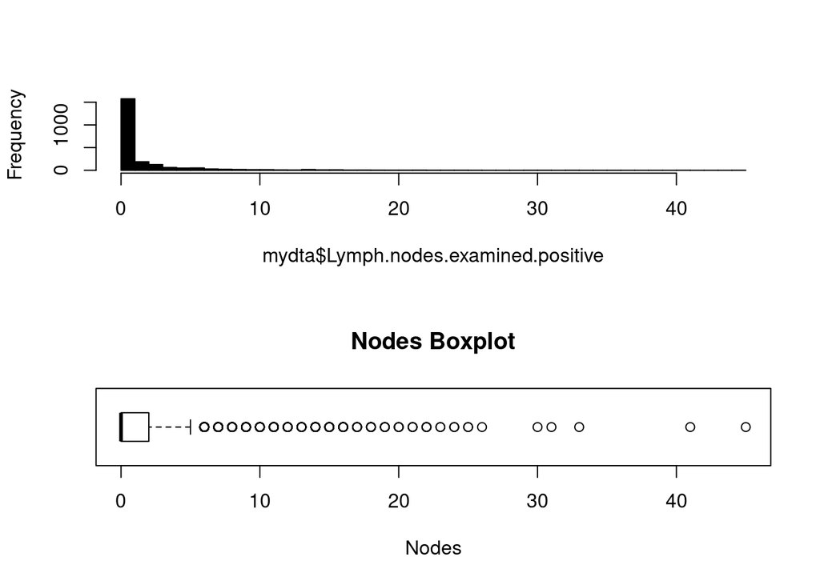

```r
par(mfrow=c(2,1))

hist(mydta$Lymph.nodes.examined.positive, breaks=seq(0,max(mydta$Lymph.nodes.examined.positive, na.rm=TRUE), by=1), col=1, main="")

boxplot(mydta$Lymph.nodes.examined.positive, xlab="Nodes", main="Nodes Boxplot", horizontal=TRUE)
```

If we wish to tabulate the number per category, then `table()` can be used as follows.

```r
table(mydta$Lymph.nodes.examined.positive)
```

```
##
##    0    1    2    3    4    5    6    7    8    9   10   11   12   13   14   15
## 1196  379  189  127   63   49   52   29   22   18   14   14    9    7   17   10
##   16   17   18   19   20   21   22   23   24   25   26   30   31   33   41   45
##   11    5    6    4    3    3    4    2    2    2    1    1    1    1    1    1
```

## Tumour size

Next consider the same plots but for tumour size (in mm).

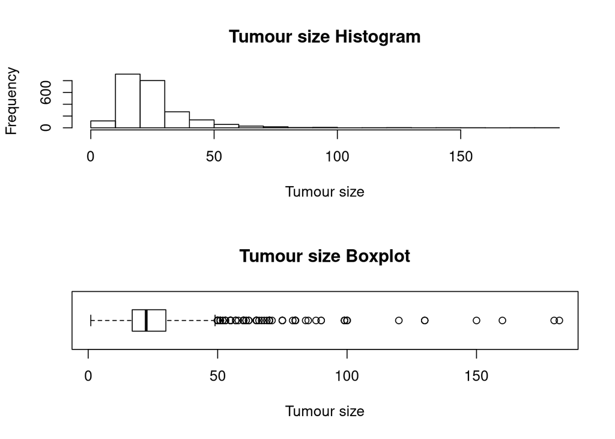

```r
par(mfrow=c(2,1))

hist(mydta$Tumor.Size, xlab="Tumour size", main="Tumour size Histogram")

boxplot(mydta$Tumor.Size, xlab="Tumour size", main="Tumour size Boxplot", horizontal=TRUE)
```

## Tumour size vs Lymph nodes

Finally, we look at the association between tumour size and lymph nodes. It is expected that larger tumours are more likely to have spread to other parts of the body, and so the two should be positively correlated. We examine their association next.

First, we plot the data

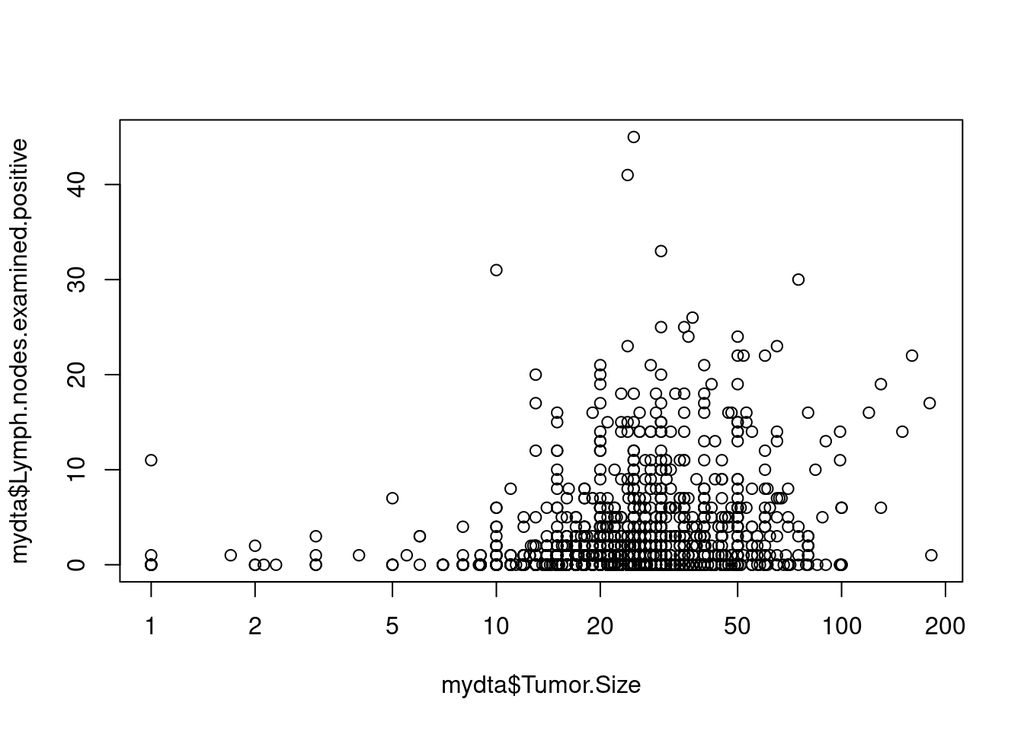

```r
plot(mydta$Tumor.Size, mydta$Lymph.nodes.examined.positive, log="x")
```

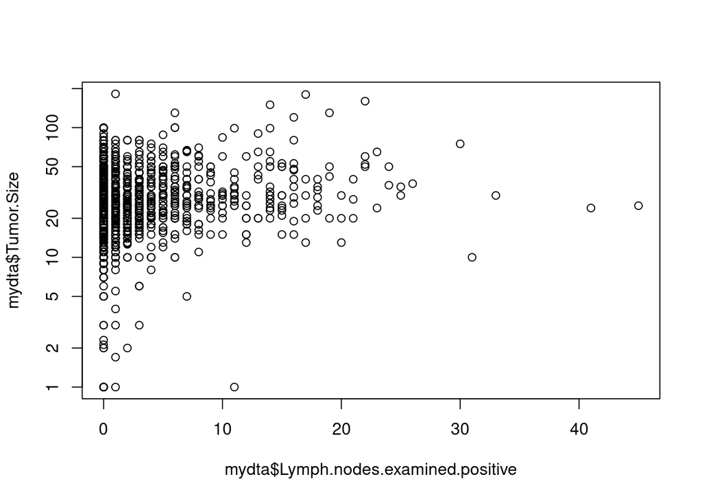

```r
plot(mydta$Lymph.nodes.examined.positive,mydta$Tumor.Size, log="y")
```

This plots size vs nodes, and nodes vs size. We use the `log="x"` argument to put the x-axis on a log scale. This is sometimes useful for insepction of the plots, particularly when some data is a long way from the bulk.

Next let us define node positive vs negative in the data frame, and use this to get summary statistics of tumour size by nodal statue (neg/pos).

```r
mydta$LNpos =  mydta$Lymph.nodes.examined.positive >0

tapply(mydta$Tumor.Size, mydta$LNpos, summary)
```

```
## $`FALSE`
##    Min. 1st Qu.  Median    Mean 3rd Qu.    Max.    NA's
##    1.00   15.00   20.00   23.41   27.00  100.00      25
##
## $`TRUE`
##    Min. 1st Qu.  Median    Mean 3rd Qu.    Max.    NA's
##    1.00   20.00   25.00   29.92   35.00  182.00      11
```

We can also plot the distribution of tumour size by nodal status as follows.

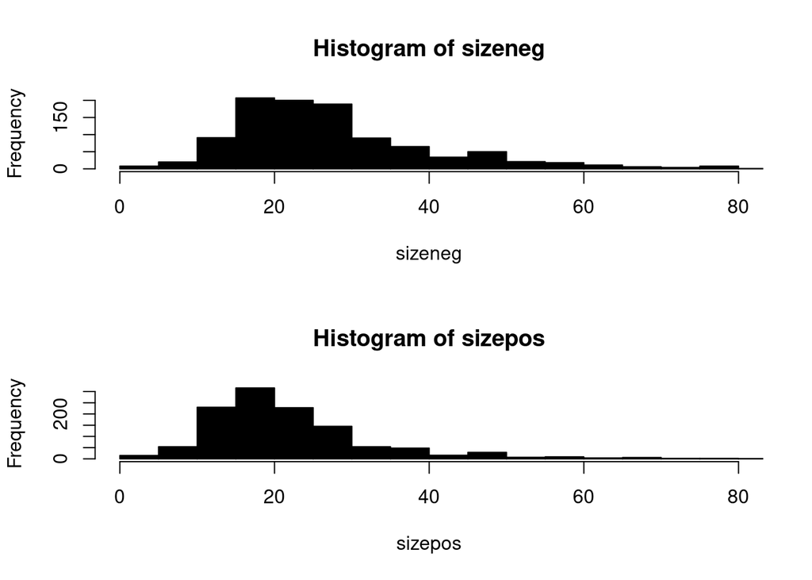

```r
sizeneg = subset(mydta$Tumor.Size, mydta$LNpos)

sizepos = subset(mydta$Tumor.Size, !mydta$LNpos)

par(mfrow=c(2,1))

hist(sizeneg, xlim=c(0,80), breaks=seq(0,200,by=5), col=1)

hist(sizepos, xlim=c(0,80), breaks=seq(0,200,by=5), col=1)
```

To test the hypothesis that mean tumour size is the same in both (independent) groups one might use a t-test, or a non-parametric Wilcoxon test.

```r
t.test(sizeneg, sizepos)
```

```
##
##  Welch Two Sample t-test
##
## data:  sizeneg and sizepos
## t = 9.9674, df = 1821.4, p-value < 2.2e-16
## alternative hypothesis: true difference in means is not equal to 0
## 95 percent confidence interval:
##  5.226586 7.787309
## sample estimates:
## mean of x mean of y
##  29.91937  23.41243
```

```r
wilcox.test(sizeneg, sizepos)
```

```
##
##  Wilcoxon rank sum test with continuity correction
##
## data:  sizeneg and sizepos
## W = 780892, p-value < 2.2e-16
## alternative hypothesis: true location shift is not equal to 0
```

One might sometimes be interested in particular cutpoints. For tumour size, 20mm is a cutpoint used in tumour staging, so we look at that next.

First we calculate the number sized more than 20mm positive by nodal status

```r
npos = c(sum(sizeneg>20, na.rm=TRUE), sum(sizepos>20, na.rm=TRUE))

ntot = c(sum(!is.na(sizeneg)), sum(!is.na(sizepos)))

## number size >20mm
npos
```

```
## [1] 710 556
```

```r
## number with size available
ntot
```

```
## [1] 1036 1171
```

```r
## proportion
npos / ntot
```

```
## [1] 0.6853282 0.4748079
```

Then we can carry a test of the difference in two proportions (based on a z-test) as follows

```r
prop.test(npos, ntot)
```

```
##
##  2-sample test for equality of proportions with continuity correction
##
## data:  npos out of ntot
## X-squared = 98.747, df = 1, p-value < 2.2e-16
## alternative hypothesis: two.sided
## 95 percent confidence interval:
##  0.1693903 0.2516503
## sample estimates:
##    prop 1    prop 2
## 0.6853282 0.4748079
```

# Now your turn..

Keep exploring!